# Mixed Effects Models

### Random Intercepts Model (Unconditional Means Model)

\[y_{i} = \alpha_{j[i]} + \epsilon_{i}\] \[\alpha_j \sim N(\mu_{\alpha}, \sigma_{\alpha}^2)\] \[\epsilon_i \sim N(0, \sigma_y^2)\]

- \(y_i\) is the logarithm of the radon measurement in house \(i\).
- \(\alpha_{j[i]}\) is a random effect of county \(j\). It is the mean of the logarithm of radon measurements in all houses in county \(j\).
- \(\mu_{\alpha}\) is the mean of the logarithm of radon measurements in all houses across all counties.
- \(\sigma_{\alpha}^2\) is the variance between counties.
- \(\sigma_{y}^2\) is the variance within a county.

### Varying-Intercept, Fixed-Slope Model

\[y_{i} = \alpha_{j[i]} + \beta (floor)_i + \epsilon_{i}\] \[\alpha_j \sim N(\mu_{\alpha}, \sigma_{\alpha}^2)\] \[\epsilon_i \sim N(0, \sigma_y^2)\]

- \(y_i\) is the logarithm of the radon measurement in house \(i\).
- \(\alpha_{j[i]}\) is a random effect of county \(j\). It is the mean of the logarithm of radon measurements taken at the basement in all houses in county \(j\).
- \(\beta\) is the average difference between the logarithm of radon measurements taken on the first floor and the logarithm of radon measurements taken at the basement.
- \(\mu_{\alpha}\) is the mean of the logarithm of radon measurements taken at the basement in all houses across all counties.
- \(\sigma_{\alpha}^2\) is the variance between counties.
- \(\sigma_{y}^2\) is the variance within a county.

### Varying-Intercept, Varying Slope Model

\[y_{i} = \alpha_{j[i]} + \beta_{j[i]} (floor)_i + \epsilon_{i}\] \[\alpha_j \sim N(\mu_{\alpha}, \sigma_{\alpha}^2)\] \[\beta_j \sim N(\mu_{\beta}, \sigma_{\beta}^2)\] \[\epsilon_i \sim N(0, \sigma_y^2)\]

- \(y_i\) is the logarithm of the radon measurement in house \(i\).
- \(\alpha_{j[i]}\) is a random effect of county \(j\). It is the mean of the logarithm of radon measurements taken at the basement in all houses in county \(j\).
- \(\beta_{j[i]}\) is another random effect of county \(j\). It is the average difference between the logarithm of radon measurements taken on the first floor and the logarithm of radon measurements taken at the basement in all houses in county \(j\).
- \(\mu_{\alpha}\) is the mean of the logarithm of radon measurements taken at the basement in all houses across all counties.
- \(\mu_{\beta}\) is the mean of the difference between the logarithm of radon measurements taken on the first floor and the logarithm of radon measurements taken at the basement in all houses across all counties.
- \(\sigma_{\alpha}^2\) and \(\sigma_{\beta}^2\) are variances between counties.
- \(\sigma_{y}^2\) is the variance within a county.

**Model with a Unit-Level Predictor**

and a Group-Level Predictor

```r
countyDataset <- read.table("cty.dat", header = T, sep = ",")
countyDataset <- dplyr::select(countyDataset, st, ctfips, Uppm) %>%
                 filter(st == "MN") %>%
                 rename(cntyfips = ctfips) %>%
                 mutate(uranium = log(Uppm)) %>%
                 dplyr::select(-st, -Uppm)
countyDataset <- countyDataset[!duplicated(countyDataset), ]
radonDataset <- merge(radonDataset, countyDataset, all.x = T)
radonDataset <- dplyr::select(radonDataset, idnum, county, logRadon, floor, uranium) %>%
                arrange(idnum)
head(radonDataset, 10)
```

```
   idnum county   logRadon floor    uranium
1   5081 AITKIN  0.7884574     1 -0.6890476
2   5082 AITKIN  0.7884574     0 -0.6890476
3   5083 AITKIN  1.0647107     0 -0.6890476
4   5084 AITKIN  0.0000000     0 -0.6890476
5   5085  ANOKA  1.1314021     0 -0.8473129
6   5086  ANOKA  0.9162907     0 -0.8473129
7   5087  ANOKA  0.4054651     0 -0.8473129
8   5088  ANOKA  0.0000000     0 -0.8473129
9   5089  ANOKA -0.3566749     0 -0.8473129
10  5090  ANOKA  0.1823216     0 -0.8473129
```

\[y_{i} = \alpha_{j[i]} + \beta_1 (floor)_i + \beta_2 (uranium)_{j[i]} + \epsilon_{i}\] \[\alpha_j \sim N(\mu_{\alpha}, \sigma_{\alpha}^2)\] \[\epsilon_i \sim N(0, \sigma_y^2)\]

- \(y_i\) is the logarithm of the radon measurement in house \(i\).
- \(\alpha_{j[i]}\) is a random effect of county \(j\).
- \(\beta_1\) is the average difference between the logarithm of radon measurements taken on the first floor and the logarithm of radon measurements taken at the basement controlling for the effect of uranium.
- \(\beta_2\) is the average change in the logarithm of the radon measurement for each unit change in uranium.
- \(\mu_{\alpha}\) is the mean of the random intercepts from all the counties.
- \(\sigma_{\alpha}^2\) is the variance between counties.
- \(\sigma_{y}^2\) is the variance within a county.

```r
M8 <- lmer(logRadon ~ floor + uranium + (1|county), data = radonDataset)
summary(M8)
```

\(\hspace{0.25in}\)

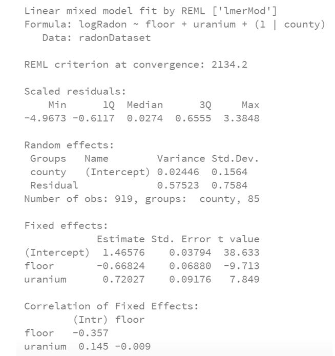

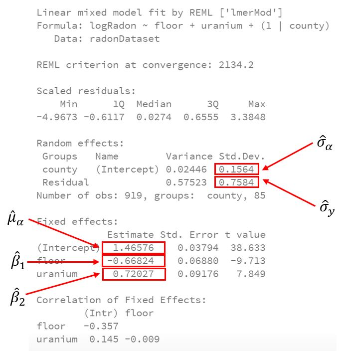

```r
M8 <- lmer(logRadon ~ floor + uranium + (1|county), data = radonDataset)
summary(M8)
```

```r
head(coef(M8)$county, 5)
```

```
         (Intercept)      floor   uranium
AITKIN      1.445120 -0.6682448 0.7202676
ANOKA       1.477009 -0.6682448 0.7202676
BECKER      1.478185 -0.6682448 0.7202676
BELTRAMI    1.576891 -0.6682448 0.7202676
BENTON      1.473999 -0.6682448 0.7202676
```

```r
fixef(M8)
```

```
(Intercept)       floor     uranium
  1.4657628  -0.6682448   0.7202676
```

```r
head(ranef(M8)$county, 5)
```

```
          (Intercept)
AITKIN   -0.020642363
ANOKA     0.011245769
BECKER    0.012422028
BELTRAMI  0.111128434
BENTON    0.008235846
```

Comparing models M6 and M8:

```r
anova(M6, M8)
```

```
Data: radonDataset
Models:
M6: logRadon ~ floor + (1 | county)
M8: logRadon ~ floor + uranium + (1 | county)
   Df    AIC    BIC  logLik deviance  Chisq Chi Df Pr(>Chisq)
M6  4 2171.7 2190.9 -1081.8   2163.7
M8  5 2132.8 2156.9 -1061.4   2122.8 40.834      1  1.658e-10 ***
---
Signif. codes:  0 '***' 0.001 '**' 0.01 '*' 0.05 '.' 0.1 ' ' 1
```

```r
sigmas <- arm::sigma.hat(M8)$sigma
sigmas
```

```
$data
[1] 0.7584393

$county
(Intercept)
  0.1564023
```

```r
icc <- sigmas$county^2/(sigmas$county^2 + sigmas$data^2)
icc
```

```
(Intercept)
 0.04079041
```

### Prediction

```r
radonDataset$prediction <- predict(M8, newdata = radonDataset, allow.new.levels = T)
head(radonDataset, 10)
```

```
   idnum county   logRadon floor    uranium prediction
1   5081 AITKIN  0.7884574     1 -0.6890476  0.2805770
2   5082 AITKIN  0.7884574     0 -0.6890476  0.9488218
3   5083 AITKIN  1.0647107     0 -0.6890476  0.9488218
4   5084 AITKIN  0.0000000     0 -0.6890476  0.9488218
5   5085  ANOKA  1.1314021     0 -0.8473129  0.8667166
6   5086  ANOKA  0.9162907     0 -0.8473129  0.8667166
7   5087  ANOKA  0.4054651     0 -0.8473129  0.8667166
8   5088  ANOKA  0.0000000     0 -0.8473129  0.8667166
9   5089  ANOKA -0.3566749     0 -0.8473129  0.8667166
10  5090  ANOKA  0.1823216     0 -0.8473129  0.8667166
```

```r
newdata = data.frame(county = "NEW COUNTY", floor = 1, uranium = -0.6890476)
predict(M8, newdata = newdata, allow.new.levels = T)
```

```
        1
0.3012194
```

```r
x <- model.matrix(logRadon ~ floor + uranium, radonDataset)
beta <- fixef(M8)
x[1, names(beta)] %*% beta
```

```
          [,1]
[1,] 0.3012194
```

```r
library(merTools)
predictInterval(M8, newdata = newdata)
```

```
        fit      upr        lwr
1 0.3662563 1.339723 -0.6089062
```

```r
newdata$county <- "AITKIN"
predictInterval(M8, newdata = newdata)
```

```
        fit      upr        lwr
1 0.3431255 1.341088 -0.6709021
```